# Programa de Especialización en R para Ciencia de Datos

Intermedio - Laboratorio 01 - Jerárquicos y No Jerárquicos

Docente: Cinthia Zavala

2021

[figure not shown]

```r
knitr::include_graphics("PortadaR.png")
```

#### **Caso: Situación demográfica de los departamentos de Lima**

Este es un conjunto de datos demográficos de distritos del departamento de Lima.

Dataset: distritos.sav

*Información de las características ( atributos o variables)*

1. distrito: nombre del distrito
2. ocu_vivi: hogares en cada vivienda
3. pobpjov: % de población en pueblos jóvenes
4. sinelect: % de población sin electricidad
5. sinagua: % de población sin agua
6. pea1619: PEA entre 16 y 19 años
7. pocprin: % de población de 6-19 con primaria incompleta
8. peam 15: PEA menores de 15 años

*Actividades*

1.- Encontrar el número optimo de cluster’s usando métodos jerárquicos

2.- Encontrar el número optimo de cluster’s usando métodos no jerárquicos

### **Comienza actividad 1**

*Cargar librería*

*Cargar datos*

```r
distritos1 <-as.data.frame(read_sav("distritos.sav"))
names(distritos1)
```

```
## [1] "distrito" "ocu_vivi" "pobpjov"  "sinelect" "sinagua"  "pea1619"  "pocprin"
## [8] "peam15"
```

*Cambiar el nombre de las filas por la variable distrito.*

```r
nombres=distritos1[,1]
distritos=distritos1[,-1]
row.names(distritos)=nombres
head(distritos)
```

```
##            ocu_vivi pobpjov sinelect sinagua pea1619 pocprin peam15
## Ate            1.15     5.3    27.60   51.10     3.9     1.1  63.48
## Barranco       1.09     4.5     1.59    8.32     0.8     3.9  33.48
## Breña          1.08     4.4     2.20   23.15     0.9     4.0  37.89
## Carabayllo     1.10     5.1    30.13   38.09     4.5    12.6  63.65
## Comas          1.20     5.9    10.92   24.27     3.8     9.4  60.37
## Chorrillos     1.15     5.5    16.77   37.11     3.2    10.6  18.78
```

*Cargar lbreria para comenzar el clustering jerarquico*

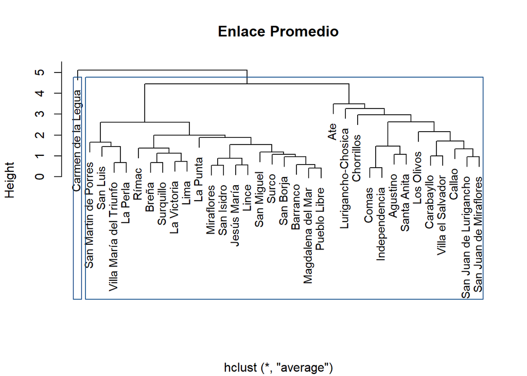

```r
hc.average<- hclust(dist(scale(distritos)),method ="average")
plot(hc.average,labels=distritos1[,1],main= "Enlace Promedio", xlab="",cex=.9)
hclust1.1<-cutree(hc.average,k=2)
rect.hclust(hc.average,2,border = "dodgerblue4")
```

```r
par(mfrow=c(1,1))
agnes_average=agnes(scale(distritos),method="average")
agnes_average
```

```
## Call:     agnes(x = scale(distritos), method = "average")
## Agglomerative coefficient:  0.7534594
## Order of objects:
##  [1] Ate                     Carabayllo              Villa el Salvador
##  [4] San Juan de Lurigancho  San Juan de Miraflores  Callao
##  [7] Los Olivos              Comas                   Independencia
## [10] Agustino                Santa Anita             Chorrillos
## [13] Lurigancho-Chosica      Barranco                Magdalena del Mar
## [16] Pueblo Libre            San Borja               Surco
## [19] San Miguel              Jesús María             Lince
## [22] Miraflores              San Isidro              La Punta
## [25] Breña                   Surquillo               La Victoria
## [28] Lima                    Rímac                   San Luis
## [31] Villa María del Triunfo La Perla                San Martin de Porres
## [34] Carmen de la Legua
## Height (summary):
##    Min. 1st Qu.  Median    Mean 3rd Qu.    Max.
##  0.4162  0.8894  1.3389  1.6387  1.9956  5.0973
##
## Available components:
## [1] "order"     "height"    "ac"        "merge"     "diss"      "call"
## [7] "method"    "order.lab" "data"
```

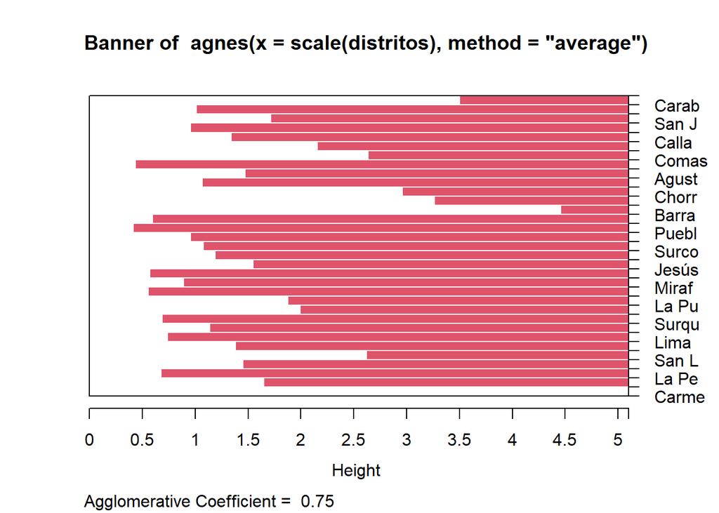

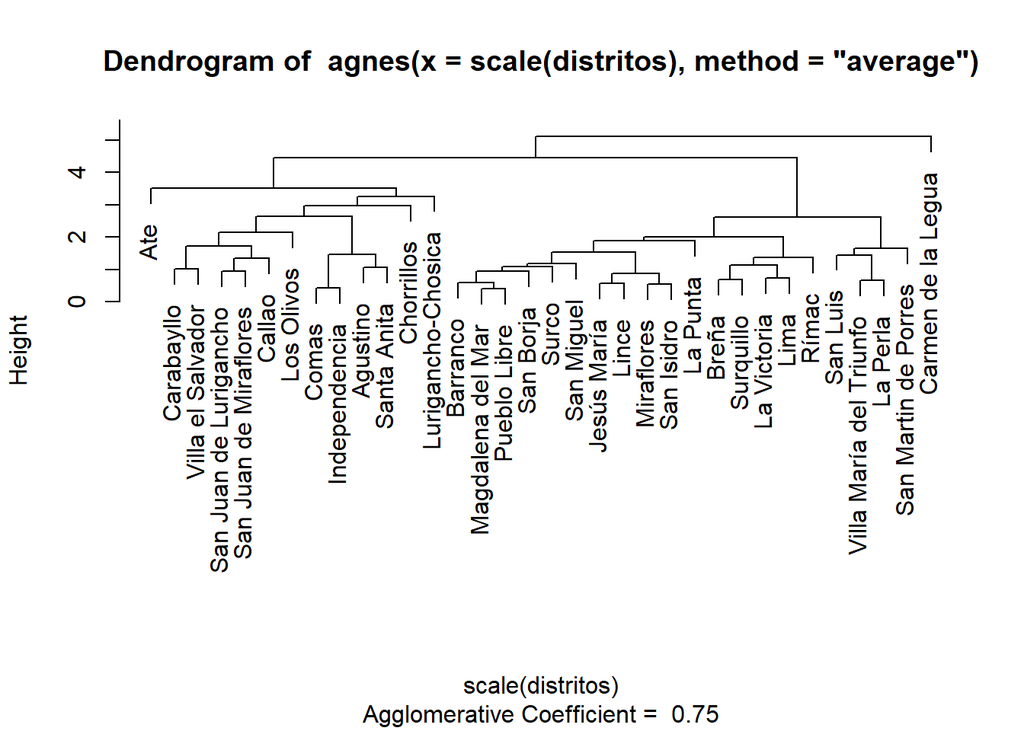

```r
plot(agnes_average)
```

Se observa que coeficiente aglomerativo arrojado con el metodo de promedio es bueno (0.75).

*Enlace Método de Ward*

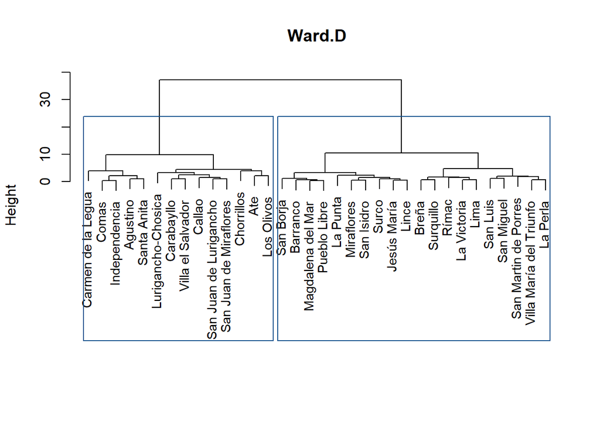

```r
hc.ward=hclust(dist(scale(distritos)), method="ward.D")
plot(hc.ward, labels=distritos1[,1],main="Ward.D", xlab="", sub="", cex=.9)

hclust.2 <- cutree(hc.ward,k=2)
rect.hclust(hc.ward,2,border = "dodgerblue4")
```

```r
agnes_ward =agnes(scale(distritos),method="ward")
agnes_ward
```

```
## Call:     agnes(x = scale(distritos), method = "ward")
## Agglomerative coefficient:  0.9232787
## Order of objects:
##  [1] Ate                     Los Olivos              Carabayllo
##  [4] Villa el Salvador       San Juan de Lurigancho  San Juan de Miraflores
##  [7] Callao                  Lurigancho-Chosica      Comas
## [10] Independencia           San Martin de Porres    Agustino
## [13] Santa Anita             Chorrillos              Carmen de la Legua
## [16] Barranco                Magdalena del Mar       Pueblo Libre
## [19] San Borja               Jesús María             Lince
## [22] Surco                   Miraflores              San Isidro
## [25] La Punta                Breña                   Surquillo
## [28] La Victoria             Lima                    Rímac
## [31] San Luis                San Miguel              Villa María del Triunfo
## [34] La Perla
## Height (summary):
##    Min. 1st Qu.  Median    Mean 3rd Qu.    Max.
##  0.4162  0.9582  1.4594  2.4255  2.7261 15.9549
##
## Available components:
## [1] "order"     "height"    "ac"        "merge"     "diss"      "call"
## [7] "method"    "order.lab" "data"
```

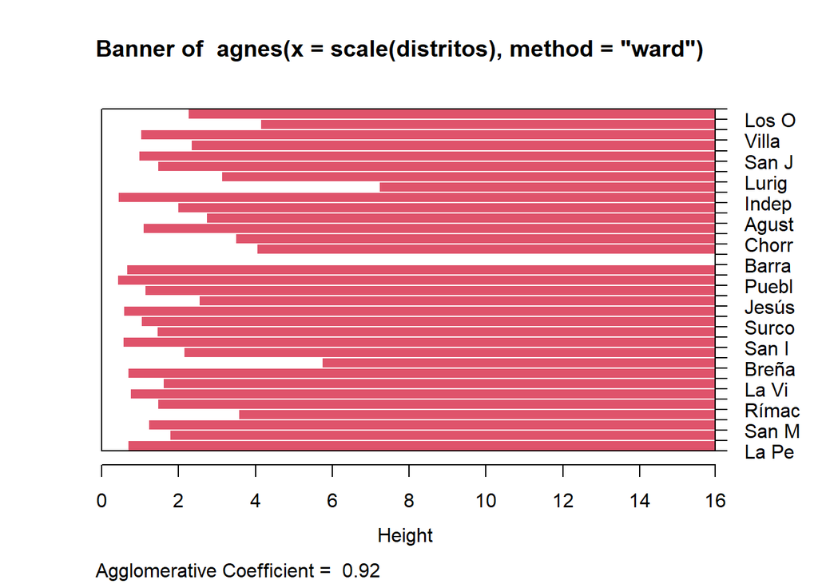

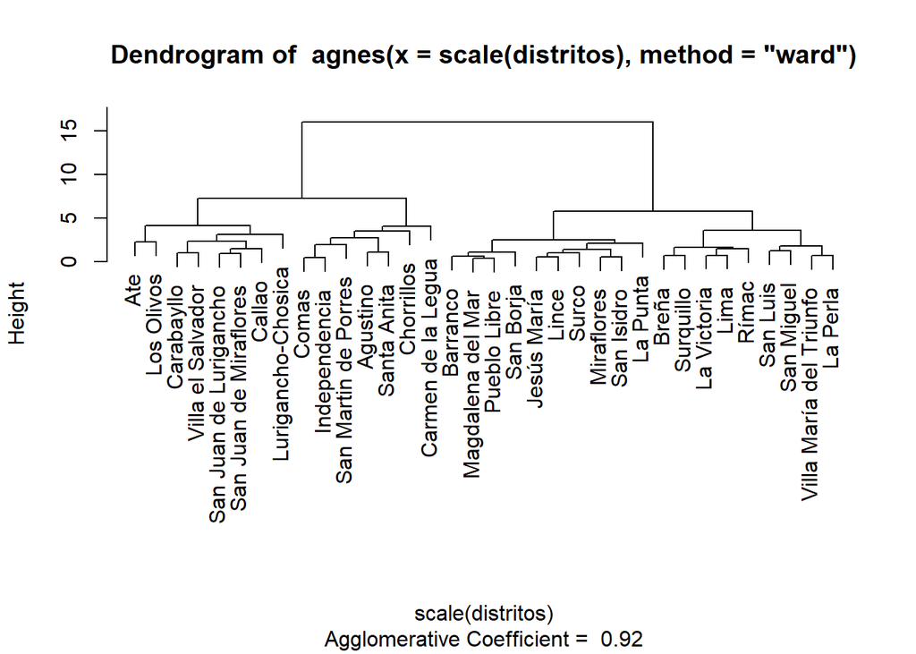

```r
plot(agnes_ward)
```

A pesar de que el metodo Average habia arrojado un buen coeficiente de aglomeracion (0.75), se procedera a trabajar con el modelo arrojado por el metodo de Ward, debido a su coeficiente sumamente mejorado de 0.92.

A continuacion se procedera a evaluar el numero ideal de clusters por medio del coeficiente de silueta.

*Encontrar la matriz de distancias*

```r
dis.distritos=daisy(scale(distritos))
```

*Coeficiente de Silueta con 2 clústers*

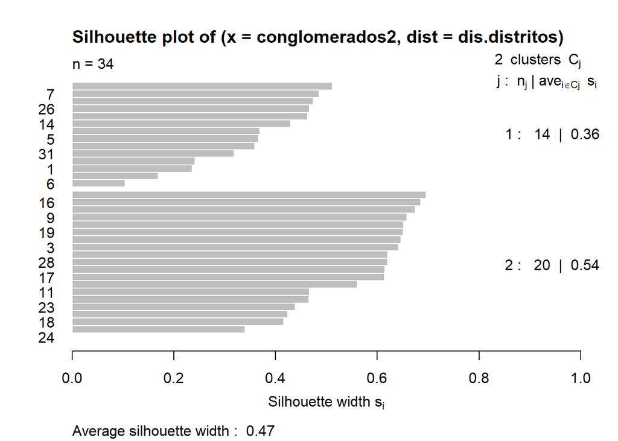

```r
conglomerados2=cutree(hc.ward,2)
plot(silhouette(conglomerados2,dis.distritos))
```

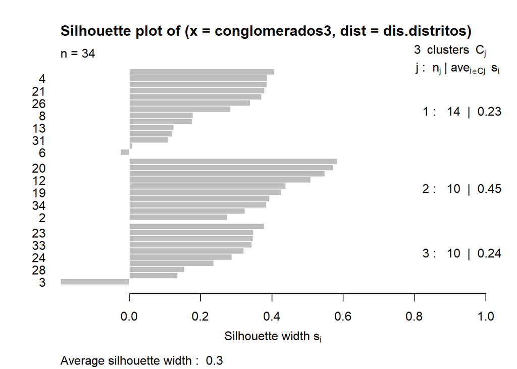

```r
conglomerados3=cutree(hc.ward,3)
plot(silhouette(conglomerados3,dis.distritos))
```

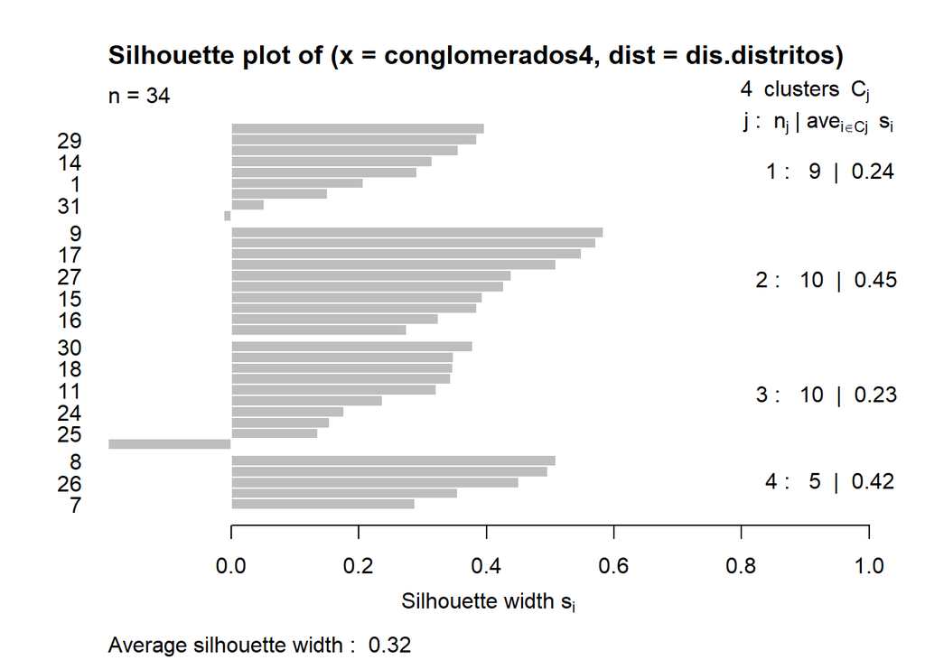

```r
conglomerados4=cutree(hc.ward,4)
plot(silhouette(conglomerados4,dis.distritos))
```

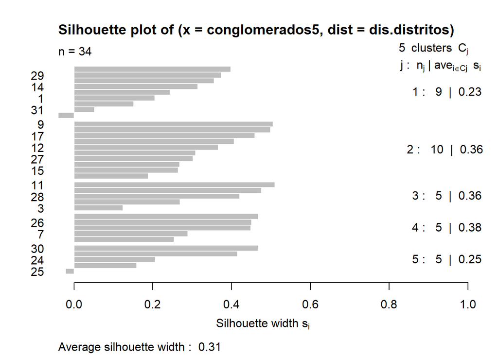

```r
conglomerados5=cutree(hc.ward,5)
plot(silhouette(conglomerados5,dis.distritos))
```

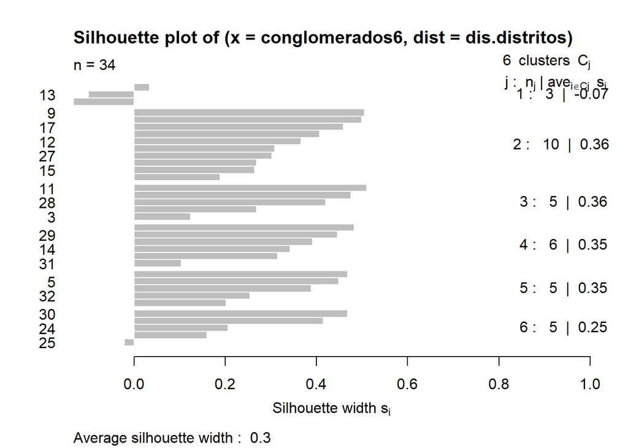

```r
conglomerados6=cutree(hc.ward,6)
plot(silhouette(conglomerados6,dis.distritos))
```

Dados los coeficientes de silueta obtenidos, se elegirán 2 clústers.

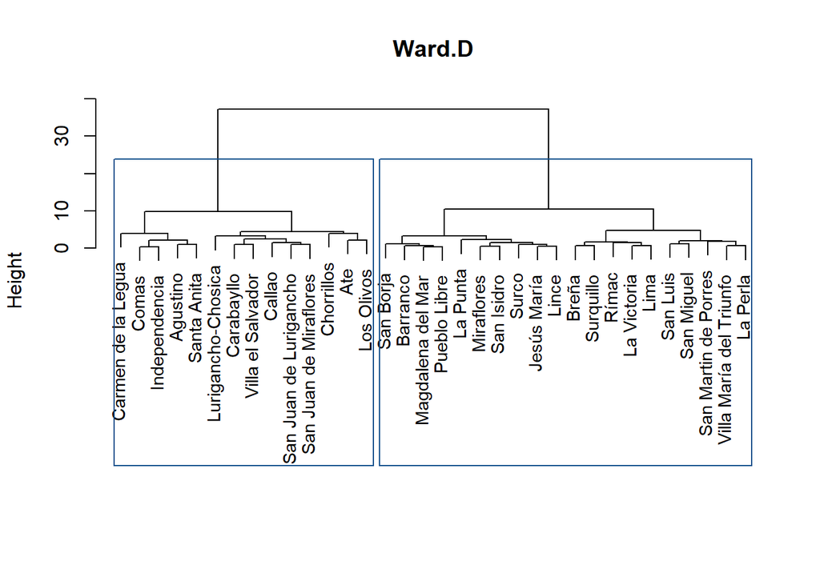

```r
hc.ward=hclust(dist(scale(distritos)), method="ward.D")
plot(hc.ward, labels=distritos1[,1],main="Ward.D", xlab="", sub="", cex=.9)

hclust.2 <- cutree(hc.ward,k=2)
rect.hclust(hc.ward,2,border = "dodgerblue4")
```

#### **Clúster Jerárquico Divisivo**

**DIANA**

```r
clus_diana<- diana(scale(distritos))

clus_diana
```

```
## Merge:
##       [,1] [,2]
##  [1,]  -15  -16
##  [2,]   -5   -8
##  [3,]  -17  -20
##  [4,]   -9  -12
##  [5,]   -2    1
##  [6,]  -30  -33
##  [7,]  -10  -11
##  [8,]  -21  -22
##  [9,]   -4  -29
## [10,]    4    3
## [11,]   -7  -26
## [12,]    7  -28
## [13,]    5  -19
```

[output cut: 45 more lines]

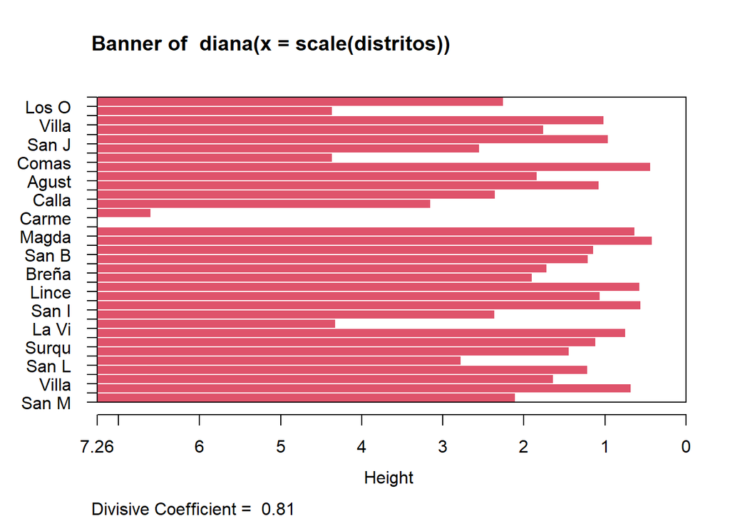

```r
plot(clus_diana)
```

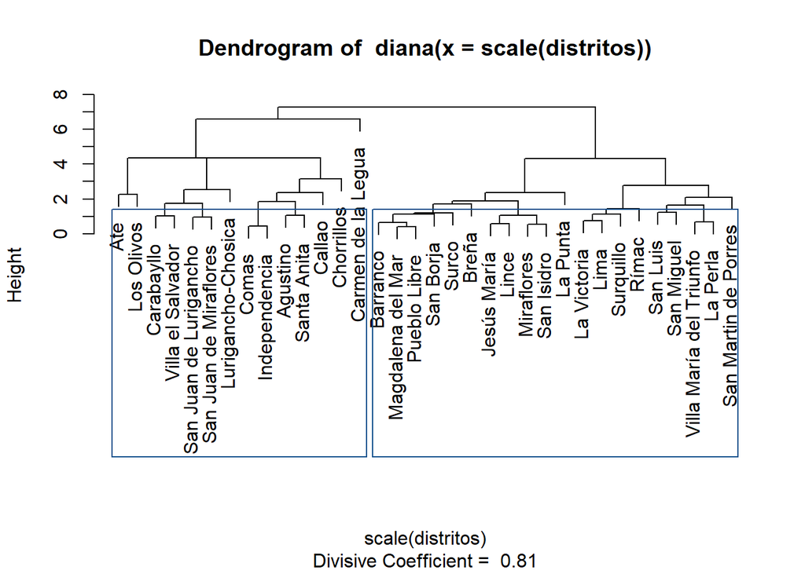

```r
rect.hclust(clus_diana,2,border = "dodgerblue4")
```

*Encontrar el número optimo con el coeficiente de silueta.*

```r
dis.distritos2=daisy(scale(distritos))
```

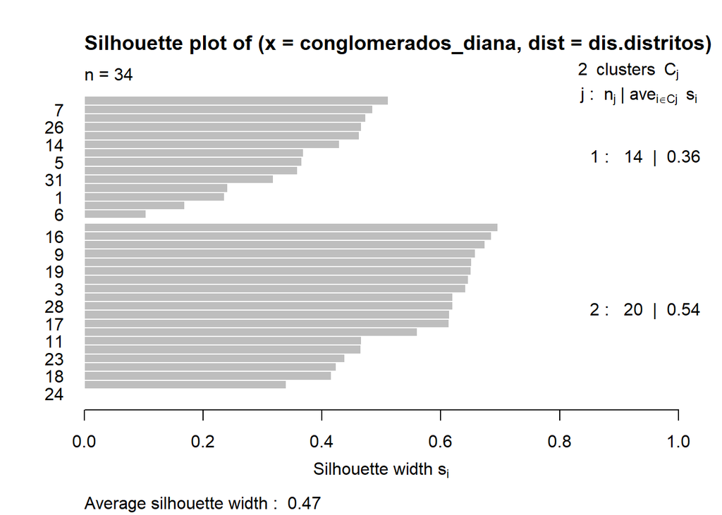

```r
conglomerados_diana=cutree(clus_diana,2)
plot(silhouette(conglomerados_diana,dis.distritos))
```

*Evaluar con 3 clústers como varia el coeficiente.*

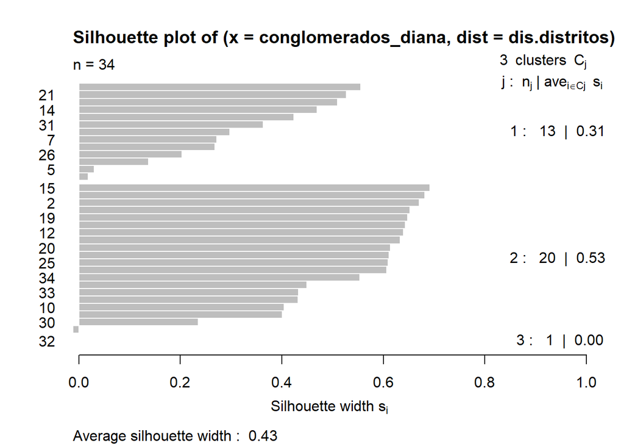

```r
conglomerados_diana=cutree(clus_diana,3)
plot(silhouette(conglomerados_diana,dis.distritos))
```

### **Considerando los resultados anteriores, se determina que el número ideal de clusters es 2.**

## **Comienza actividad 2**

*Cargar librerias*

*Eliminar elementos nulos*

```r
distritos <- na.omit(distritos)
```

*Escalar los datos para eliminar sesgos derivados de la diferencia de escala*

```r
distritos <- scale(distritos)
head(distritos, 7)
```

```
##              ocu_vivi    pobpjov   sinelect     sinagua    pea1619    pocprin
## Ate         0.5141271  0.4196783  1.7499821  1.74573667  1.0621925 -1.7577466
## Barranco   -0.3822997 -0.7947101 -0.7909902 -1.13426254 -0.8327820 -0.9430559
## Breña      -0.5317041 -0.9465086 -0.7313980 -0.13588974 -0.7716537 -0.9139598
## Carabayllo -0.2328952  0.1160812  1.9971432  0.86988838  1.4289618  1.5883046
## Comas       1.2611495  1.3304696  0.1204774 -0.06049004  1.0010643  0.6572295
## Chorrillos  0.5141271  0.7232754  0.6919763  0.80391365  0.6342951  1.0063827
## Agustino    1.5599584  1.4822682  0.6577841  1.07656434  1.4289618  1.8501695
##                peam15
## Ate         1.2474999
## Barranco   -0.5844703
## Breña      -0.3151707
## Carabayllo  1.2578811
## Comas       1.0575856
## Chorrillos -1.4821358
## Agustino    0.7809581
```

*Calcular la Matriz de distancias por euclidean (default)*

```r
distancias <- get_dist(distritos)
```

*Visualizar las similitudes de distancias entre los distritos*

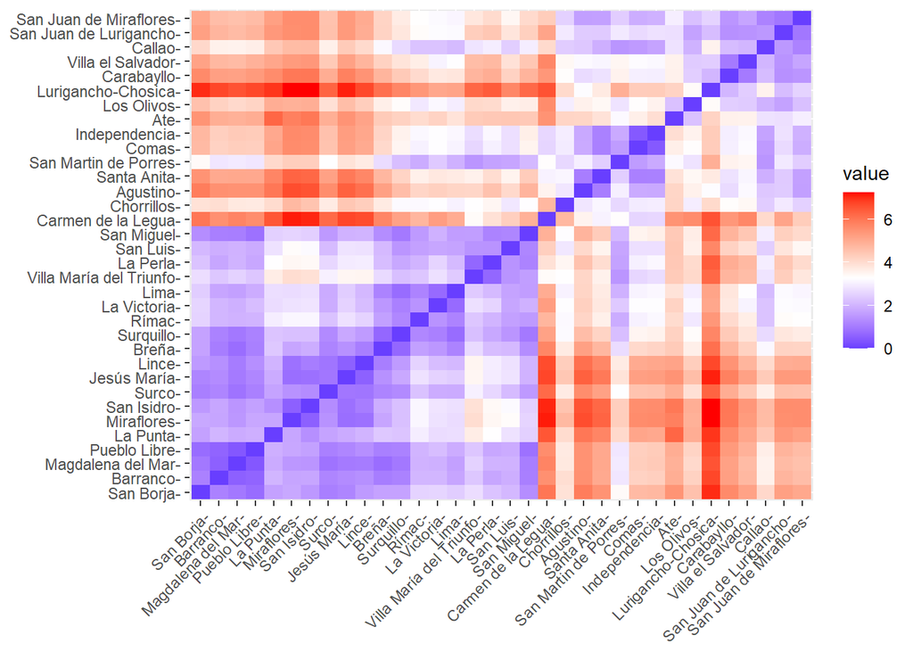

```r
fviz_dist(distancias, gradient = list(low = "blue", mid = "white", high = "red"))
```

#### **Modelo Kmeans**

```r
k2 <- kmeans(distritos, centers = 2, nstart = 25)

str(k2)
```

```
## List of 9
##  $ cluster     : Named int [1:34] 1 2 2 1 1 1 1 1 2 2 ...
##   ..- attr(*, "names")= chr [1:34] "Ate" "Barranco" "Breña" "Carabayllo" ...
##  $ centers     : num [1:2, 1:7] 0.664 -0.524 0.754 -0.595 0.896 ...
##   ..- attr(*, "dimnames")=List of 2
##   .. ..$ : chr [1:2] "1" "2"
##   .. ..$ : chr [1:7] "ocu_vivi" "pobpjov" "sinelect" "sinagua" ...
##  $ totss       : num 231
##  $ withinss    : num [1:2] 67.3 36.5
##  $ tot.withinss: num 104
##  $ betweenss   : num 127
##  $ size        : int [1:2] 15 19
##  $ iter        : int 1
##  $ ifault      : int 0
##  - attr(*, "class")= chr "kmeans"
```

*Graficar los clusters*

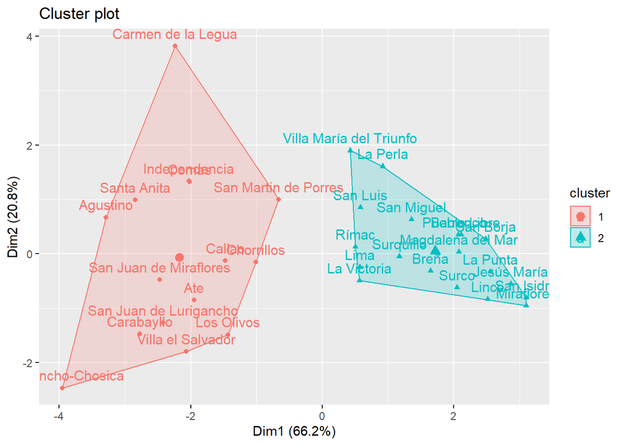

```r
fviz_cluster(k2, data = distritos)
```

**EVALUAR DIFERENTES MODELOS**

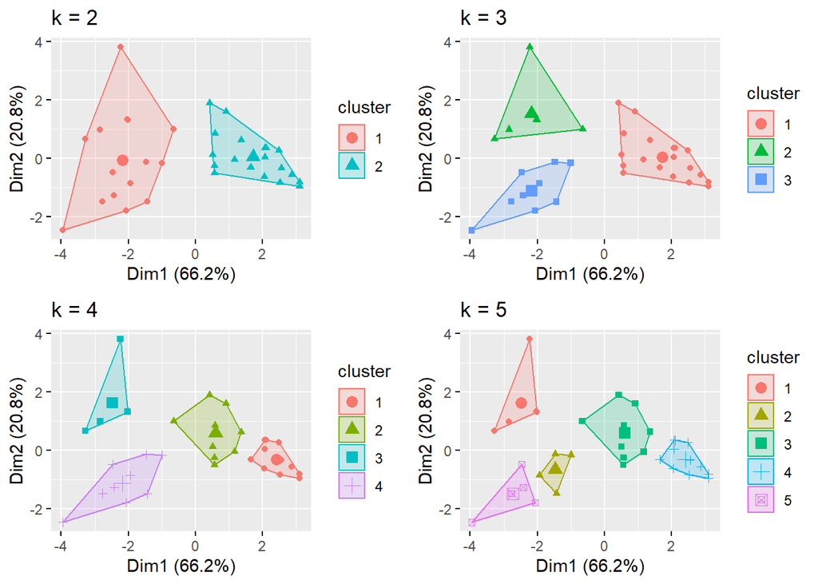

```r
# Se prueba a realizar clusters con 2,3,4 y 5 grupos

k3 <- kmeans(distritos, centers = 3, nstart = 25)
k4 <- kmeans(distritos, centers = 4, nstart = 25)
k5 <- kmeans(distritos, centers = 5, nstart = 25)

# Se preparan los grupos para ser visualizarlos
p1 <- fviz_cluster(k2, geom = "point", data = distritos) + ggtitle("k = 2")
p2 <- fviz_cluster(k3, geom = "point", data = distritos) + ggtitle("k = 3")
p3 <- fviz_cluster(k4, geom = "point", data = distritos) + ggtitle("k = 4")
p4 <- fviz_cluster(k5, geom = "point", data = distritos) + ggtitle("k = 5")

# Visualizar los clusters con los diferentes grupos calculados
grid.arrange(p1, p2, p3, p4, nrow = 2)
```

Visualmente, el modelo que parece estar más separado es el de 2 clústeres (esquina superior izquierda).

**OPTIMIZAR EL MODELO**

*1) Elbow Method*

*Fijar semilla*

```r
set.seed(123)
```

*Definir una función para calcular la suma total del cuadrado dentro de los grupos del cluster*

```r
wss <- function(k) {
  kmeans(distritos, k, nstart = 10 )$tot.withinss
}
```

*Definir el número de cluster a probar entre 1 y 15*

```r
num_clusters <- 1:15
```

*Extraer los valores de “wss” de los clusters*

```r
wss_values <- map_dbl(num_clusters, wss)
```

*Preparar visualización de los clusters*

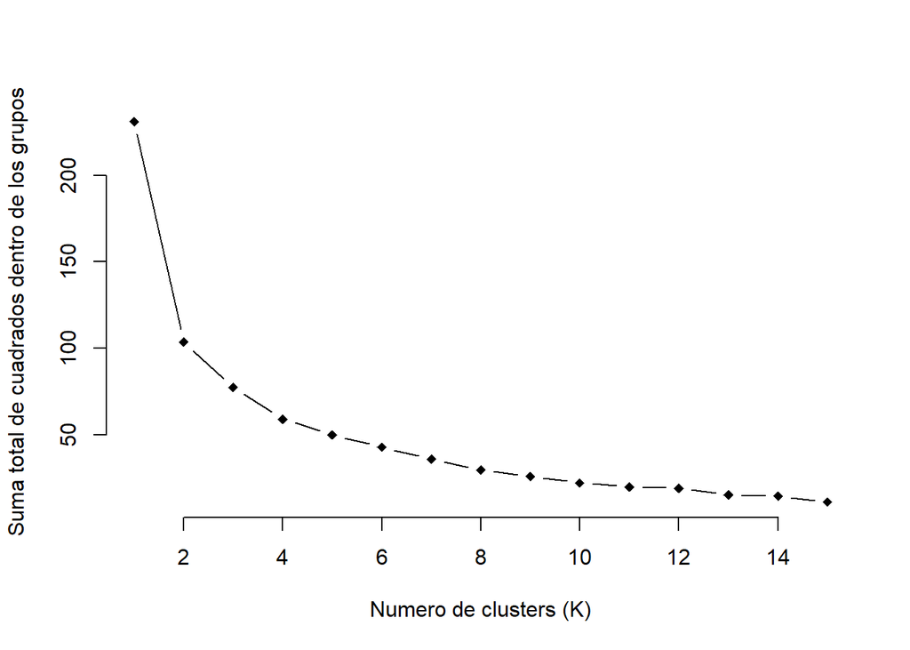

```r
plot(num_clusters, wss_values,
     type="b", pch = 18, frame = FALSE,
     xlab="Numero de clusters (K)",
     ylab="Suma total de cuadrados dentro de los grupos")
```

Como se observa en el gráfico, el mayor decremento se observa en 2 clústeres.

*Visualizar los resultados que comparan la suma total del cuadrado de las distancias existentes para cada cluster*

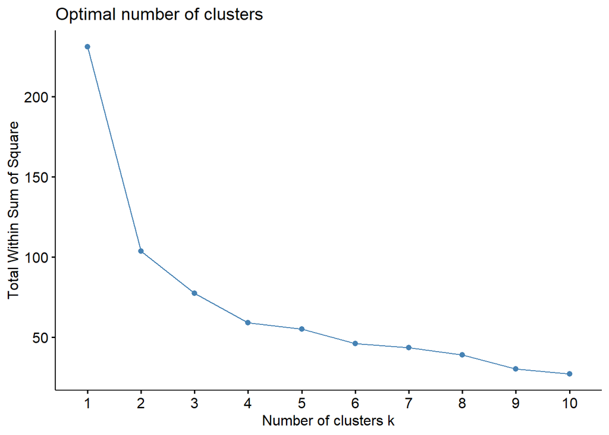

```r
fviz_nbclust(distritos, kmeans, method = "wss")
```

Al igual que el gráfico anterior, esete gráfico indica que el número óptimo de clústeres es 2.

*2) Average Silhouette Method*

Optimiza que cada elemento se encuadre lo mejor posible dentro de la silueta del grupo. El alto y ancho de las siluetas de los grupos es un buen indicador de la calidad del agrupamiento

## *Función para calcular el promedio de las siluetas*

```r
avg_sil <- function(k) {
  km.res <- kmeans(distritos, centers = k, nstart = 25)
  ss <- silhouette(km.res$cluster, dist(distritos))
  mean(ss[, 3])
}
```

*Definir el número de cluster a probar entre 2 y 15*

```r
k.values <- 2:15
```

*Extraemos la media de los valores calculados*

```r
avg_sil_values <- map_dbl(k.values, avg_sil)
```

*Visualizar los resultados para diferentes numeros de grupos*

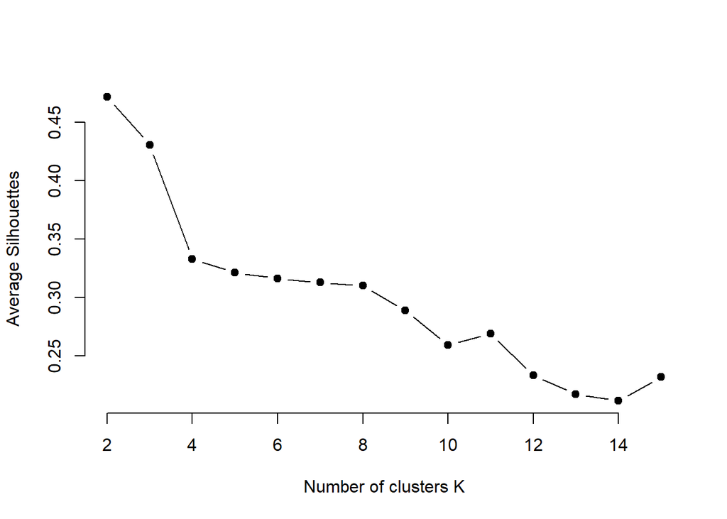

```r
plot(k.values, avg_sil_values,
     type = "b", pch = 19, frame = FALSE,
     xlab = "Number of clusters K",
     ylab = "Average Silhouettes")
```

Al igual que Elbow method, Average Silhouettes indican que el mejor número de clústeres es 2.

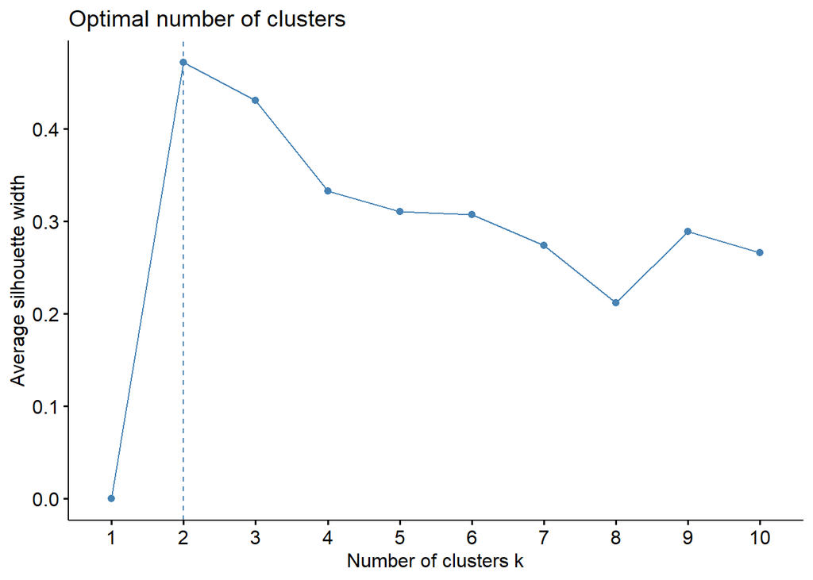

```r
fviz_nbclust(distritos, kmeans, method = "silhouette")
```

De acuerdo con el gráfico, el numero optimo de clusters sigue siendo 2.

*3) Gap Statistic Method*

*Función que calcula el gap de cada elemento dentro del grupo utilizando la simulación de Monte Carlo.*

```r
gap_stat <- clusGap(distritos, FUN = kmeans, nstart = 25,
                    K.max = 10, B = 50)
```

*Vizualizacion de los resultados obtenidos por la funcion anterior*

```r
print(gap_stat, method = "firstmax")
```

```
## Clustering Gap statistic ["clusGap"] from call:
## clusGap(x = distritos, FUNcluster = kmeans, K.max = 10, B = 50,     nstart = 25)
## B=50 simulated reference sets, k = 1..10; spaceH0="scaledPCA"
##  --> Number of clusters (method 'firstmax'): 2
##           logW   E.logW       gap     SE.sim
##  [1,] 3.331743 3.549153 0.2174107 0.04874584
##  [2,] 2.916442 3.313064 0.3966214 0.04100587
##  [3,] 2.773296 3.142396 0.3690999 0.03295980
##  [4,] 2.607068 3.017949 0.4108816 0.03486039
##  [5,] 2.515169 2.913635 0.3984658 0.03610665
##  [6,] 2.432884 2.818586 0.3857015 0.03780158
##  [7,] 2.341871 2.731887 0.3900166 0.03625374
##  [8,] 2.229194 2.649956 0.4207620 0.03783084
##  [9,] 2.128247 2.569515 0.4412679 0.03930313
## [10,] 2.031436 2.492387 0.4609507 0.04348152
```

*Visualizar los resultados que comparan el gap existente para cada cluster*

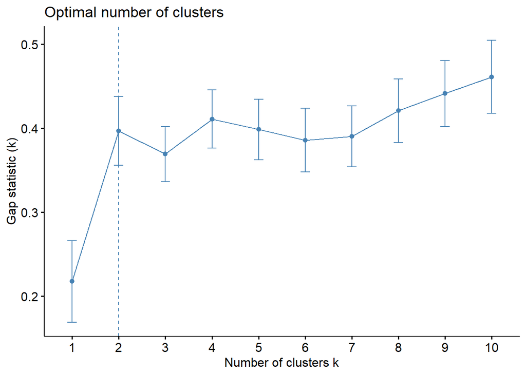

```r
fviz_gap_stat(gap_stat)
```

De forma similar que los métodos anteriores, el método Gap indica que el número ótimo de clústeres es 2.

## **CLUSTER RESULTANTE TRAS OPTIMIZAR EL MODELO**

*Se visualiza el cluster que optimiza el número de grupos*

```r
final <- kmeans(distritos, 2, nstart = 25)
```

*Se muestran las características propias del cluster generado*

```r
print(final)
```

```
## K-means clustering with 2 clusters of sizes 15, 19
##
## Cluster means:
##     ocu_vivi    pobpjov   sinelect    sinagua    pea1619    pocprin     peam15
## 1  0.6635316  0.7536352  0.8957621  0.7981240  0.9978041  0.7677947  0.8420238
## 2 -0.5238407 -0.5949751 -0.7071806 -0.6300979 -0.7877401 -0.6061537 -0.6647556
##
## Clustering vector:
##                     Ate                Barranco                   Breña
##                       1                       2                       2
##              Carabayllo                   Comas              Chorrillos
##                       1                       1                       1
##                Agustino           Independencia             Jesús María
##                       1                       1                       2
##             La Victoria                    Lima                   Lince
##                       2                       2                       2
##              Los Olivos      Lurigancho-Chosica       Magdalena del Mar
##                       1                       1                       2
##            Pueblo Libre              Miraflores                   Rímac
##                       2                       2                       2
##               San Borja              San Isidro  San Juan de Lurigancho
##                       2                       2                       1
##  San Juan de Miraflores                San Luis    San Martin de Porres
##                       1                       2                       1
##              San Miguel             Santa Anita                   Surco
##                       2                       1                       2
##               Surquillo       Villa el Salvador Villa María del Triunfo
##                       2                       1                       2
##                  Callao      Carmen de la Legua                La Perla
##                       1                       1                       2
##                La Punta
##                       2
##
## Within cluster sum of squares by cluster:
## [1] 67.25282 36.46842
##  (between_SS / total_SS =  55.1 %)
##
## Available components:
##
## [1] "cluster"      "centers"      "totss"        "withinss"     "tot.withinss"
## [6] "betweenss"    "size"         "iter"         "ifault"
```

Con lo anterior, se observa que el modelo está explicando el 55% de la variabilidad de los datos. No es muy bueno en realidad, pero es utilizable. Se podría mejorar si se incrementara el número de datos.

*Visualizamos los resultados del cluster óptimo*

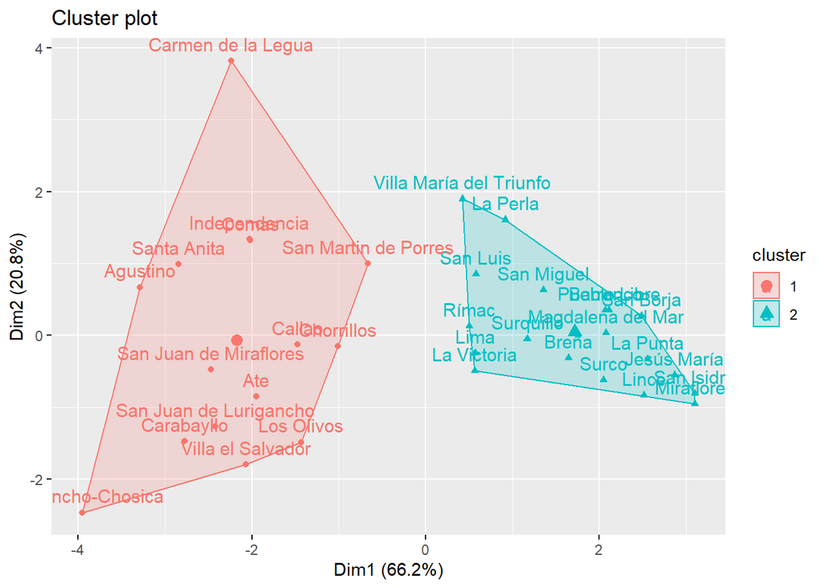

```r
fviz_cluster(final, data = distritos)
```

```r
distritos1 %>%
  mutate(Cluster = final$cluster) %>%
  group_by(Cluster) %>%
  summarise_all("mean")
```

```
## # A tibble: 2 x 9
##   Cluster distrito ocu_vivi pobpjov sinelect sinagua pea1619 pocprin peam15
##     <int>    <dbl>    <dbl>   <dbl>    <dbl>   <dbl>   <dbl>   <dbl>  <dbl>
## 1       1       NA     1.16    5.52    18.9     37.0   3.79     9.78   56.8
## 2       2       NA     1.08    4.63     2.45    15.8   0.874    5.06   32.2
```

*Generamos una nueva copia para almacenar los grupos.*

```r
data_agrupada<- distritos1

data_agrupada$grupos<-final$cluster

head(data_agrupada)
```

```
##     distrito ocu_vivi pobpjov sinelect sinagua pea1619 pocprin peam15 grupos
## 1        Ate     1.15     5.3    27.60   51.10     3.9     1.1  63.48      1
## 2   Barranco     1.09     4.5     1.59    8.32     0.8     3.9  33.48      2
## 3      Breña     1.08     4.4     2.20   23.15     0.9     4.0  37.89      2
## 4 Carabayllo     1.10     5.1    30.13   38.09     4.5    12.6  63.65      1
## 5      Comas     1.20     5.9    10.92   24.27     3.8     9.4  60.37      1
## 6 Chorrillos     1.15     5.5    16.77   37.11     3.2    10.6  18.78      1
```

**Otros Algoritmos**

*PAM*

```r
pam_2<-pam(distritos,2)
pam_3<-pam(distritos,3)
pam_4<-pam(distritos,4)
pam_5<-pam(distritos,5)
par(mfrw=c(2,2))
```

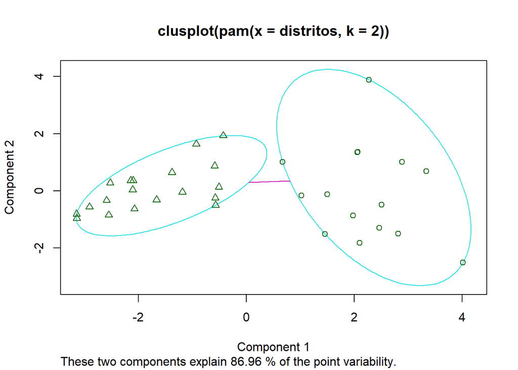

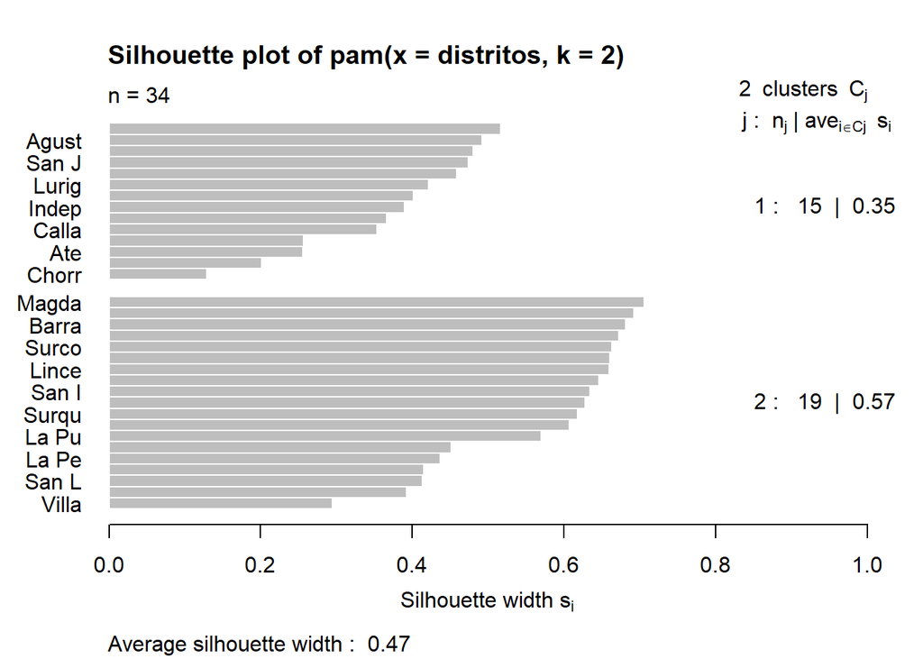

```r
plot(pam_2)
```

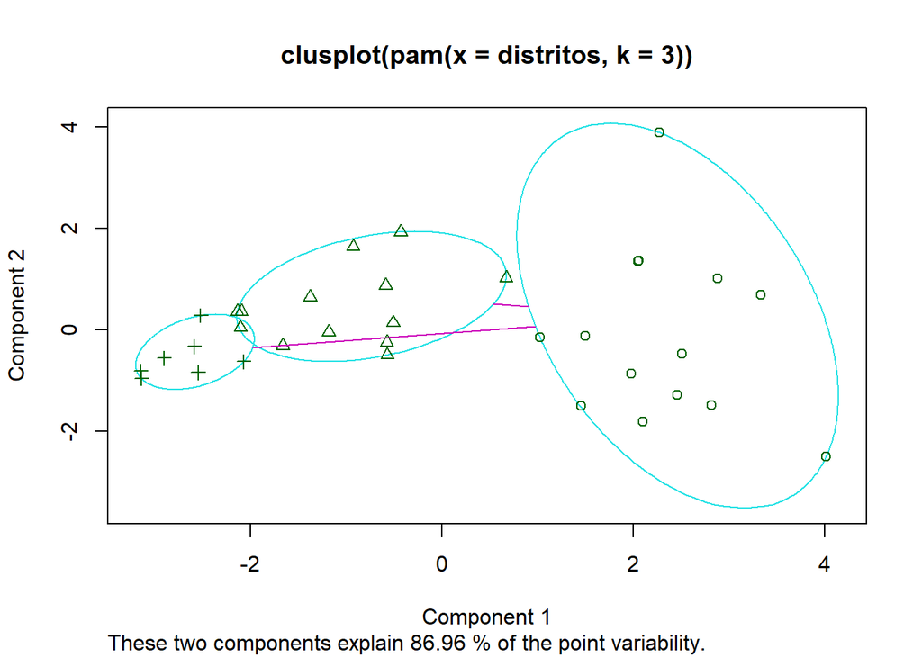

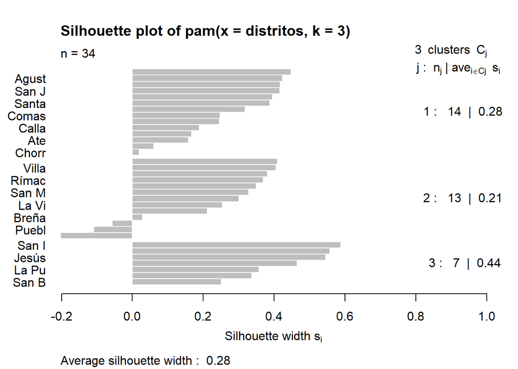

```r
plot(pam_3)
```